# Credit Score Classification

Final Project for DTSA 5509 (Introduction to Machine Learning)  
by Yasushi Yamanaka (yasushi.yamanaka@colorado.edu)

## 1. Introduction

### 1.1 Background

Credit scores are crucial for determining if someone can get a loan or credit. Traditionally, experts used statistical models to calculate these scores. But now, machine learning methods are changing the game. Machine learning algorithms can analyze a lot of data and find patterns that humans might miss. This project focuses on using machine learning to classify credit scores. By training algorithms on past credit data, we can teach them to identify important patterns and make accurate predictions about someone's creditworthiness. We'll use different classification algorithms for comparison. The goal is to create a reliable credit scoring model that lenders can use to assess risk and make better decisions. This will help them reduce financial risks while offering loans to deserving individuals.

### 1.2 Objectives

This project is about building machine learning models on credit-related bank data. The data is originated from Kaggle and the problem belongs to *multiclass classification problem of supervised learning*. Different classification algorithms will be tested and compared in this project, including Logistic Regression, Decision Tree Classification, Random Forest Classification, and Gradient Boosting Classification. Comparison will be based on classification evaluation metrics and time efficiency. Optimal model with good balance of accuracy and efficiency is recommended at the of the study based on testing results. In addition, data handling and analysis techniques required for model training will be demostrated.

### 1.3 Data Source

- ROHAN PARIS. (2022). Credit score classification. [Data Set] https://www.kaggle.com/datasets/parisrohan/credit-score-classification
- Origin and gathering method of this dataset are not revealed in the website
- Problem Statement from the website: *You are working as a data scientist in a global finance company. Over the years, the company has collected basic bank details and gathered a lot of credit-related information. The management wants to build an intelligent system to segregate the people into credit score brackets to reduce the manual efforts.*

```python
import numpy as np
import pandas as pd
import matplotlib as mpl
import matplotlib.pyplot as plt
import seaborn as sns
import sklearn
import sklearn.model_selection
import sklearn.linear_model
import sklearn.tree
import sklearn.ensemble
import sklearn.preprocessing
import statsmodels.stats.outliers_influence
import yellowbrick.classifier
import warnings
warnings.filterwarnings('ignore')

%matplotlib inline
```

## 2. Data Loading

### 2.1 Training vs Testing Data

There are two files train.csv and test.csv from the data soucre. The former has target labels and the latter hasn't. According to the objectives of the current study, we ignore the test one and split the train one into to training data set and validation/test data set in the following data handling part.

```python
df = pd.read_csv("data/train.csv")
#df_test = pd.read_csv("data/test.csv")
```

### 2.2 Data Description

- File Size: 45MB
- Number of Table: 1
- Number of rows: 100,000
- Column Counts: 28
- Numeric Column Counts: 8
- Text Column Counts: 20
- Column of Target Variable: *Credit_Score* (Categorical Values with: **Good/Poor/Standard**)

Most of the columns are self-described as the column names of the following table. One column need further explanation is *Total_EMI_per_month* (EMI=equated monthly installment), which stands for fixed payment amount made by a borrower to a lender. Data types of the columns will be changed according to he data handling process.

```python
df.info()
```

```
<class 'pandas.core.frame.DataFrame'>
RangeIndex: 100000 entries, 0 to 99999
Data columns (total 28 columns):
 #   Column                    Non-Null Count   Dtype
---  ------                    --------------   -----
 0   ID                        100000 non-null  object
 1   Customer_ID               100000 non-null  object
 2   Month                     100000 non-null  object
 3   Name                      90015 non-null   object
 4   Age                       100000 non-null  object
 5   SSN                       100000 non-null  object
 6   Occupation                100000 non-null  object
 7   Annual_Income             100000 non-null  object
 8   Monthly_Inhand_Salary     84998 non-null   float64
 9   Num_Bank_Accounts         100000 non-null  int64
```

[output cut: 20 more lines]

### 2.3 Label Column Imbalance Check

Since the degree of imbalance is slight, special considerations will not be applied in model building.

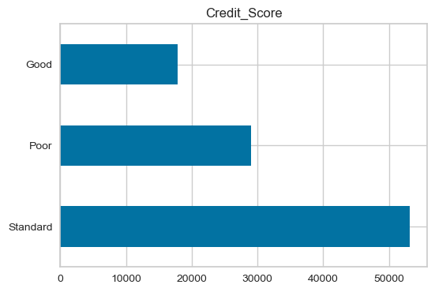

```python
fig, ax = plt.subplots(1, 1, figsize=(6, 4))
df["Credit_Score"].value_counts().plot.barh(ax=ax, title="Credit_Score");
```

## 3. Data Cleaning

### 3.1 Dropping Irrelevant Columns

Since ID, Customer_ID, Name, and SSN will not appear in future prediction, we drop these three columns. However, Customer_ID will be retained for data processing (for the purpose of grouping) and dropped afterward.

```python
columns_to_drop =["ID", "Name", "SSN"]
df.drop(columns=columns_to_drop, inplace=True)
```

### 3.2 Converting Columns to Correct Datatypes and Formats

- Columns to convert: Month, Age, Annual_Income, Num_of_Loan, Num_of_Delayed_Payment, Changed_Credit_Limit, Outstanding_Debt, Amount_invested_monthly, Monthly_Balance
- For those values converted unsuccessfully (due to invalid format), we set them as NA

```python
df["Month"] = pd.to_datetime(df["Month"], format='%B').dt.month
df["Age"] = pd.to_numeric(df["Age"],errors="coerce")
df["Annual_Income"] = pd.to_numeric(df["Annual_Income"],errors="coerce")
df["Num_of_Loan"] = pd.to_numeric(df["Num_of_Loan"], errors="coerce")
df["Num_of_Delayed_Payment"] = pd.to_numeric(df["Num_of_Delayed_Payment"], errors="coerce")
df["Changed_Credit_Limit"] = pd.to_numeric(df["Changed_Credit_Limit"], errors="coerce")
df["Outstanding_Debt"] = pd.to_numeric(df["Outstanding_Debt"], errors="coerce")
df["Amount_invested_monthly"] = pd.to_numeric(df["Amount_invested_monthly"], errors="coerce")
df["Monthly_Balance"] = pd.to_numeric(df["Monthly_Balance"], errors="coerce")
```

- Occupation, Credit_Mix, and Payment_Behaviour are categorical but have some random values, we set those random values to NA
- Credit_History_Age is in the format of XX Years and X Months, so we parse it and turn it into numeric format
- Type_fo_Loan is categorical but can have multiple values, so we standardize the format preparing for later transformation

```python
df["Occupation"][df["Occupation"] == "_______"] = pd.NA
df["Credit_Mix"][df["Credit_Mix"] == "_"] = pd.NA
df["Payment_Behaviour"][df["Payment_Behaviour"] == "!@9#%8"] = pd.NA
df["Credit_History_Age"] = df["Credit_History_Age"].apply(lambda x: float(x.split(" ")[0])*12+float(x.split(" ")[3]) if pd.notnull(x) else x)
df["Type_of_Loan"] = df["Type_of_Loan"].str.lower().apply(lambda x: x.replace(", and ", ",").replace(", ", ",") if pd.notnull(x) else x)
```

### 3.3 Outliers and Negatives Analysis

We plot boxplots of numeric columns to figure out if it is necessary to remove outliers and negatives (if positive value is required).

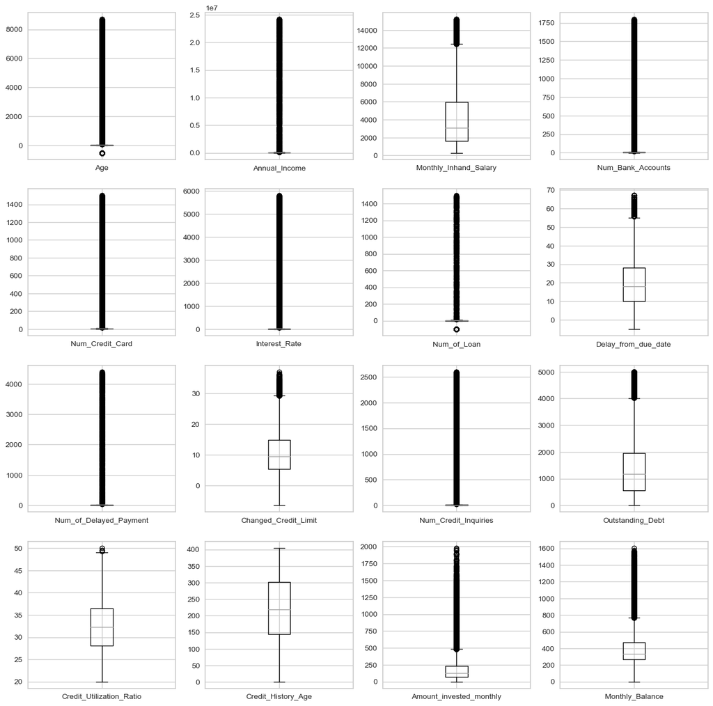

```python
fig, ax = plt.subplots(4, 4, figsize=(16, 16))
df.boxplot(column="Age", ax=ax[0][0])
df.boxplot(column="Annual_Income", ax=ax[0][1])
df.boxplot(column="Monthly_Inhand_Salary", ax=ax[0][2])
df.boxplot(column="Num_Bank_Accounts", ax=ax[0][3])

df.boxplot(column="Num_Credit_Card", ax=ax[1][0])
df.boxplot(column="Interest_Rate", ax=ax[1][1])
df.boxplot(column="Num_of_Loan", ax=ax[1][2])
df.boxplot(column="Delay_from_due_date", ax=ax[1][3])

df.boxplot(column="Num_of_Delayed_Payment", ax=ax[2][0])
df.boxplot(column="Changed_Credit_Limit", ax=ax[2][1])
df.boxplot(column="Num_Credit_Inquiries", ax=ax[2][2])
df.boxplot(column="Outstanding_Debt", ax=ax[2][3])

df.boxplot(column="Credit_Utilization_Ratio", ax=ax[3][0])
df.boxplot(column="Credit_History_Age", ax=ax[3][1])
df.boxplot(column="Amount_invested_monthly", ax=ax[3][2])
df.boxplot(column="Monthly_Balance", ax=ax[3][3]);
```

- Age, Num_Bank_Accounts, Num_Credit_Card, Interest_Rate, Num_of_Loan, Num_of_Delayed_Payment, and Num_Credit_Inquiries have obvious outliers
- We apply 1.5*IQR rule (Interquartile Range) to find outliers in data and set them to NA
- Num_Bank_Accounts, Num_Credit_Card, Delay_from_due_date, Num_of_Delayed_Payment, Changed_Credit_Limit, and Num_Credit_Inquiries require positive value but negatives exist. We set these values to NA

```python
columns_to_clear_outliers = ["Age","Num_Bank_Accounts","Num_Credit_Card","Interest_Rate","Num_of_Loan","Num_of_Delayed_Payment","Num_Credit_Inquiries"]

for col in columns_to_clear_outliers:
    q1, q3 = df[col].quantile(0.25), df[col].quantile(0.75)
    lower, upper = q1-1.5*(q3-q1), q3+1.5*(q3-q1)
    df[col][np.logical_or((df[col] > upper), (df[col] < lower))] = pd.NA

columns_to_clear_negatives = ["Num_Bank_Accounts", "Num_Credit_Card","Delay_from_due_date", "Num_of_Delayed_Payment", "Changed_Credit_Limit", "Num_Credit_Inquiries"]

for col in columns_to_clear_negatives:
    df.loc[df[df[col]<0].index, col] = pd.NA
```

### 3.4 Imputation Strategy for NA Values

- If non-na value exists with same Customer_ID, impute NA with median/model value group by Customer_ID
- If non-na value doesn't exist with same Customer_ID, impute NA with median/model value of the whole column
- Following table is NA values ratio in columns before and after the imputation process

```python
columns = (df.isna().mean() * 100).index
before = (df.isna().mean() * 100).values

obj_col = ["Customer_ID","Occupation","Type_of_Loan","Credit_Mix","Payment_of_Min_Amount","Payment_Behaviour"]
num_col = ["Age","Annual_Income","Monthly_Inhand_Salary","Num_Bank_Accounts","Num_Credit_Card","Interest_Rate","Num_of_Loan","Delay_from_due_date","Num_of_Delayed_Payment","Changed_Credit_Limit","Num_Credit_Inquiries","Outstanding_Debt","Credit_Utilization_Ratio","Credit_History_Age","Total_EMI_per_month","Amount_invested_monthly","Monthly_Balance"]

o_m = df[obj_col].groupby("Customer_ID").agg(pd.Series.mode)
n_m = df.groupby(["Customer_ID"]).median()


for col in obj_col[1:]:
    am = pd.Series.mode(df[col])
    for i in df[col][df[col].isna()].index:
        v = o_m.loc[df["Customer_ID"].iloc[i], col]
        if not isinstance(v, np.ndarray):
            df[col].iloc[i] = v
        elif len(v) > 0:
            df[col].iloc[i] = v[0]
        else:
            df[col].iloc[i] = am[0]

for col in num_col:
    for i in df[col][df[col].isna()].index:
        v = n_m.loc[df["Customer_ID"].iloc[i], col]
        df[col].iloc[i] = v

after = (df.isna().mean() * 100).values
pd.DataFrame({"Columns": columns, "Before":before, "After":after})
```

|  | Columns | Before | After |
| --- | --- | --- | --- |
| 0 | Customer_ID | 0.000 | 0.0 |
| 1 | Month | 0.000 | 0.0 |
| 2 | Age | 7.635 | 0.0 |
| 3 | Occupation | 7.062 | 0.0 |
| 4 | Annual_Income | 6.980 | 0.0 |
| 5 | Monthly_Inhand_Salary | 15.002 | 0.0 |
| 6 | Num_Bank_Accounts | 1.336 | 0.0 |
| 7 | Num_Credit_Card | 2.271 | 0.0 |
| 8 | Interest_Rate | 2.034 | 0.0 |
| 9 | Num_of_Loan | 9.108 | 0.0 |
| 10 | Type_of_Loan | 11.408 | 0.0 |
| 11 | Delay_from_due_date | 0.591 | 0.0 |
| 12 | Num_of_Delayed_Payment | 11.085 | 0.0 |
| 13 | Changed_Credit_Limit | 3.677 | 0.0 |
| 14 | Num_Credit_Inquiries | 3.615 | 0.0 |
| 15 | Credit_Mix | 20.195 | 0.0 |
| 16 | Outstanding_Debt | 1.009 | 0.0 |
| 17 | Credit_Utilization_Ratio | 0.000 | 0.0 |
| 18 | Credit_History_Age | 9.030 | 0.0 |
| 19 | Payment_of_Min_Amount | 0.000 | 0.0 |
| 20 | Total_EMI_per_month | 0.000 | 0.0 |
| 21 | Amount_invested_monthly | 8.784 | 0.0 |
| 22 | Payment_Behaviour | 7.600 | 0.0 |
| 23 | Monthly_Balance | 1.209 | 0.0 |
| 24 | Credit_Score | 0.000 | 0.0 |

### 3.5 Splitting Multi-valued Columns

- Type_of_Loan is categorical and multi-valued. We split it into 9 columns regarding to all possible values it can take

```python
s = set()
for r in df["Type_of_Loan"]:
    s.update(r.split(","))

loan_types = {t: i for i, t in enumerate(s)}

for i in range(len(loan_types)):
    df["Type_of_Loan_" + str(i)] = 0

for i in df.index:
    types = df.iloc[i]["Type_of_Loan"].split(",")
    for t in types:
        df.loc[i, "Type_of_Loan_" + str(loan_types[t])] = 1

df.drop(columns=["Type_of_Loan"], inplace=True)

print(loan_types)
```

```
{'personal loan': 0, 'student loan': 1, 'auto loan': 2, 'credit-builder loan': 3, 'home equity loan': 4, 'debt consolidation loan': 5, 'payday loan': 6, 'not specified': 7, 'mortgage loan': 8}
```

### 3.6 Data Cleaning Finished

- Columns are with proper datatypes
- Random values, outliers and out-of-range values are removed
- NA values are imputed
- Multi-valued column is transformed into multiple columns

```python
df.info()
```

```
<class 'pandas.core.frame.DataFrame'>
RangeIndex: 100000 entries, 0 to 99999
Data columns (total 33 columns):
 #   Column                    Non-Null Count   Dtype
---  ------                    --------------   -----
 0   Customer_ID               100000 non-null  object
 1   Month                     100000 non-null  int64
 2   Age                       100000 non-null  float64
 3   Occupation                100000 non-null  object
 4   Annual_Income             100000 non-null  float64
 5   Monthly_Inhand_Salary     100000 non-null  float64
 6   Num_Bank_Accounts         100000 non-null  float64
 7   Num_Credit_Card           100000 non-null  float64
 8   Interest_Rate             100000 non-null  float64
 9   Num_of_Loan               100000 non-null  float64
```

[output cut: 25 more lines]

## 4. Exploratory Data Analysis

### 4.1 Columns with Numeric Values

- After removing outliers and out-of-range values in the data cleaning section, we plot their boxplots again in the following
- Annual_Income, Monthly_Inhand_Salary, Amount_invested_monthly, and Monthly_Balance seem still having outliers according to 1.5*IQR rule, but in the context of wealth possession they are still in resonable range

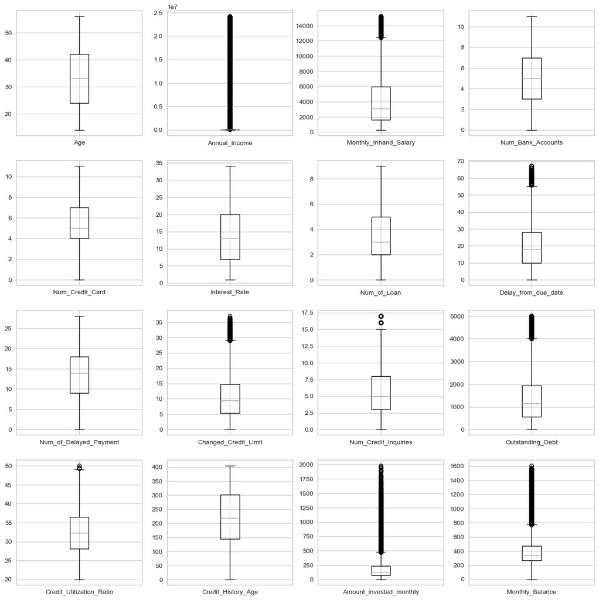

```python
fig, ax = plt.subplots(4, 4, figsize=(16, 16))
df.boxplot(column="Age", ax=ax[0][0])
df.boxplot(column="Annual_Income", ax=ax[0][1])
df.boxplot(column="Monthly_Inhand_Salary", ax=ax[0][2])
df.boxplot(column="Num_Bank_Accounts", ax=ax[0][3])

df.boxplot(column="Num_Credit_Card", ax=ax[1][0])
df.boxplot(column="Interest_Rate", ax=ax[1][1])
df.boxplot(column="Num_of_Loan", ax=ax[1][2])
df.boxplot(column="Delay_from_due_date", ax=ax[1][3])

df.boxplot(column="Num_of_Delayed_Payment", ax=ax[2][0])
df.boxplot(column="Changed_Credit_Limit", ax=ax[2][1])
df.boxplot(column="Num_Credit_Inquiries", ax=ax[2][2])
df.boxplot(column="Outstanding_Debt", ax=ax[2][3])

df.boxplot(column="Credit_Utilization_Ratio", ax=ax[3][0])
df.boxplot(column="Credit_History_Age", ax=ax[3][1])
df.boxplot(column="Amount_invested_monthly", ax=ax[3][2])
df.boxplot(column="Monthly_Balance", ax=ax[3][3]);
```

### 4.2 Columns with Categorical Values

- Values of Occupation, Credit_Mix, and Payment_Behaviour are without serious imbalance
- We cannot find out the meaning of value NM in Payment_of_Min_Amount, will come back to check this in the feature importance section

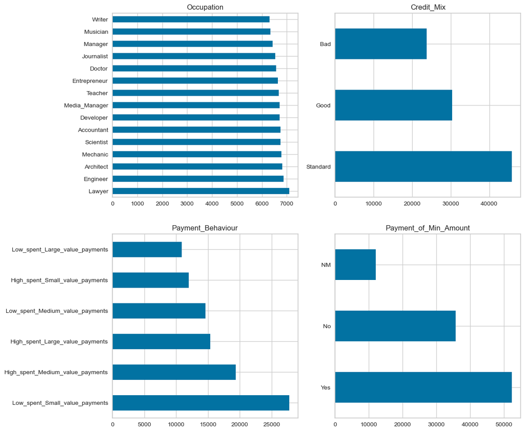

```python
fig, ax = plt.subplots(2, 2, figsize=(12, 12))
df["Occupation"].value_counts().plot.barh(ax=ax[0][0], title="Occupation")
df["Credit_Mix"].value_counts().plot.barh(ax=ax[0][1], title="Credit_Mix")
df["Payment_Behaviour"].value_counts().plot.barh(ax=ax[1][0], title="Payment_Behaviour")
df["Payment_of_Min_Amount"].value_counts().plot.barh(ax=ax[1][1], title="Payment_of_Min_Amount")
```

### 4.3 Correlation Analysis

- Since many of the features are related to ones' finanical status, it is not surprise to find out that many of the features are mutually correlated
- However, three of the four models (Decision Tree, Random Forest, and Gradient Boosting) in this study are not sensitive to multicollinearity except Logistic Regression, we will further discuss the effect of this in the modelling section

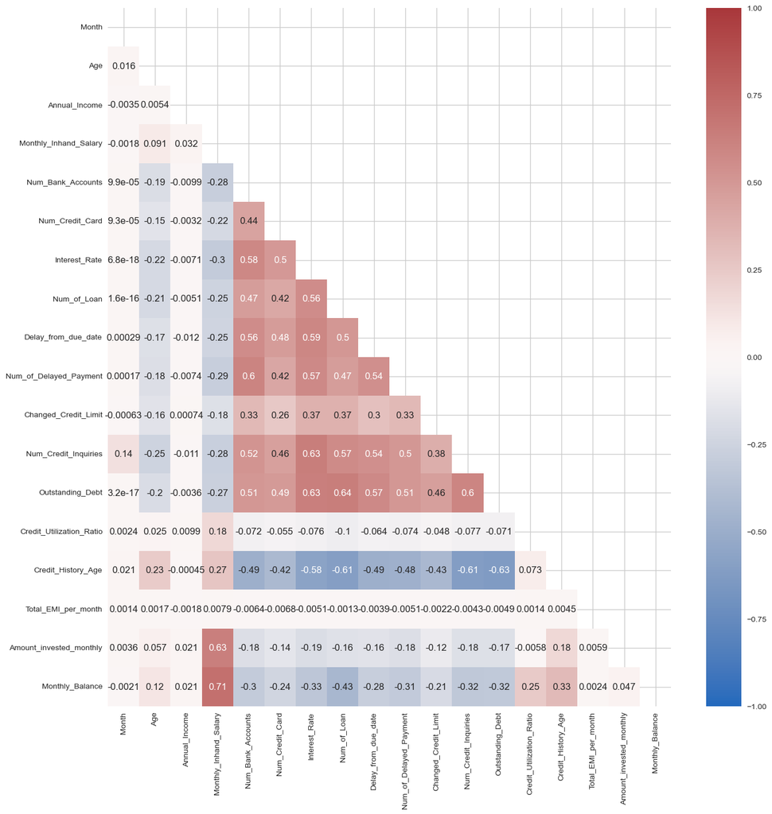

```python
fig, ax = plt.subplots(1, 1, figsize=(16, 16))
sns.heatmap(df.iloc[:, :-9].corr(), mask=np.triu(np.ones_like(df.iloc[:, :-9].corr(), dtype=bool)), annot=True, vmin=-1, vmax=1, cmap="vlag");
```

### 4.4 Conclusions and Final Preparation

- Original data missing rate (NA) of the data is not high and after applying our imputation strategy, the data looks fine and ready for machine learning models
- Features importance analysis will be deferred to the modelling section using results from the models
- MinMaxScaler is applied to normalize the data
- One final step required for putting data in models is transforming categorical data into one-hot format. It also includes encoding the target variable into ordinal format

```python
X = df.drop(columns=["Customer_ID", "Credit_Score", "Occupation", "Credit_Mix", "Payment_of_Min_Amount", "Payment_Behaviour"])
onehotencoder = sklearn.preprocessing.OneHotEncoder(sparse=False).fit(df[["Occupation", "Credit_Mix", "Payment_of_Min_Amount", "Payment_Behaviour"]])
addition = pd.DataFrame(onehotencoder.transform(df[["Occupation", "Credit_Mix", "Payment_of_Min_Amount", "Payment_Behaviour"]]), columns=onehotencoder.get_feature_names_out())
X = pd.concat([X, addition], axis=1)

scaler = sklearn.preprocessing.MinMaxScaler()
X = pd.DataFrame(scaler.fit_transform(X), columns=X.columns)
credit_score_encoder = sklearn.preprocessing.LabelEncoder().fit(df["Credit_Score"])
y = credit_score_encoder.transform(df["Credit_Score"])
```

## 5. Modelling

Since we don't have real test data, we split the training data into training set and test set.

```python
X_train, X_test, y_train, y_test = sklearn.model_selection.train_test_split(X, y, test_size=0.2)
```

### 5.1 Candidate Models

- Logistic Regression
- Decision Tree Classifier
- Random Forest Classifier
- Gradient Boosting Classifier

```python
%time lg = sklearn.linear_model.LogisticRegression(multi_class="multinomial").fit(X_train, y_train)
```

```
CPU times: total: 7.42 s
Wall time: 1.34 s
```

```python
%time tree = sklearn.tree.DecisionTreeClassifier().fit(X_train, y_train)
```

```
CPU times: total: 1.52 s
Wall time: 1.6 s
```

```python
%time forest = sklearn.ensemble.RandomForestClassifier(n_estimators=100, max_depth=25, n_jobs=-1).fit(X_train, y_train)
```

```
CPU times: total: 36.6 s
Wall time: 2.92 s
```

```python
%time boosting = sklearn.ensemble.GradientBoostingClassifier(n_estimators=100, max_depth=10).fit(X_train, y_train)
```

```
CPU times: total: 4min 36s
Wall time: 4min 54s
```

```python
def showMetrics(clfs, X_train, y_train, X_test, y_test):
    test_results, train_results = [], []
    for clf in clfs:
        y_pred_test = clf.predict(X_test)
        y_pred_train = clf.predict(X_train)
        y_pred_prob_test = clf.predict_proba(X_test)
        y_pred_prob_train = clf.predict_proba(X_train)

        accuracy_test = sklearn.metrics.accuracy_score(y_pred_test, y_test)
        precision_macro_test = sklearn.metrics.precision_score(y_pred_test, y_test, average="macro")
        recall_macro_test = sklearn.metrics.recall_score(y_pred_test, y_test, average="macro")
        f1_macro_test = sklearn.metrics.f1_score(y_pred_test, y_test, average="macro")
        auroc_macro_test = sklearn.metrics.roc_auc_score(y_test, y_pred_prob_test, multi_class="ovo")
        test_results.append([accuracy_test, precision_macro_test, recall_macro_test, f1_macro_test, auroc_macro_test])

        accuracy_train = sklearn.metrics.accuracy_score(y_pred_train, y_train)
        precision_macro_train = sklearn.metrics.precision_score(y_pred_train, y_train, average="macro")
        recall_macro_train = sklearn.metrics.recall_score(y_pred_train, y_train, average="macro")
        f1_macro_train = sklearn.metrics.f1_score(y_pred_train, y_train, average="macro")
        auroc_macro_train = sklearn.metrics.roc_auc_score(y_train, y_pred_prob_train, multi_class="ovo")
        train_results.append([accuracy_train, precision_macro_train, recall_macro_train, f1_macro_train, auroc_macro_train])

    df_test = pd.DataFrame(test_results, index=[clf.__class__.__name__ for clf in clfs],
                           columns=[["Test", "Test", "Test", "Test", "Test"],
                                    ["Accuracy", "Precision (Macro)", "Recall (Macro)", "F1 Score (Macro)", "AUROC (Macro)"]])

    df_train = pd.DataFrame(train_results, index=[clf.__class__.__name__ for clf in clfs],
                            columns=[["Train", "Train", "Train", "Train", "Train"],
                                     ["Accuracy", "Precision (Macro)", "Recall (Macro)", "F1 Score (Macro)", "AUROC (Macro)"]])
    return pd.concat([df_test, df_train], axis=1)
```

### 5.2 First Round Comparison

Metrics for multiclass classification problem

- Accuracy
- Precision (macro averaging)
- Recall (macro averaging)
- F1 Score (macro averaging)
- AUROC (macro averaging)

As we can expect, ensemble models outperform plain tree classifier and the performance of Random Forest Classifier and Gradient Boosting Classifier are comparable. Due to high dimensionality and nonlinearity of the data, Logistic Regression doesn't perform as well with other models (due to its linear nature).

```python
metrics = showMetrics([lg, tree, forest, boosting], X_train, y_train, X_test, y_test)
metrics.style.highlight_max()
```

|  | Test Accuracy | Test Precision (Macro) | Test Recall (Macro) | Test F1 Score (Macro) | Test AUROC (Macro) | Train Accuracy | Train Precision (Macro) | Train Recall (Macro) | Train F1 Score (Macro) | Train AUROC (Macro) |
| --- | --- | --- | --- | --- | --- | --- | --- | --- | --- | --- |
| LogisticRegression | 0.662700 | 0.647168 | 0.640085 | 0.639771 | 0.833687 | 0.661412 | 0.646354 | 0.639359 | 0.638895 | 0.831199 |
| DecisionTreeClassifier | 0.730850 | 0.712910 | 0.714518 | 0.713707 | 0.784683 | 1.000000 | 1.000000 | 1.000000 | 1.000000 | 1.000000 |
| RandomForestClassifier | 0.821100 | 0.815443 | 0.810852 | 0.813072 | 0.938212 | 0.993875 | 0.991354 | 0.995303 | 0.993305 | 0.999919 |
| GradientBoostingClassifier | 0.809800 | 0.801638 | 0.801096 | 0.801355 | 0.932860 | 0.944287 | 0.944320 | 0.944059 | 0.944140 | 0.994356 |

### 5.3 Feature Importance Analysis

- Model of Decision Tree Classifier, Random Forest Classifier, and Gradient Boosting Classifier provide methods of getting feature importance
- We use absolute value of feature coefficient as a proxy of feature importance in Logistic Regression
- We pick features with low importance in the following diagrams and drop them to re-train the models

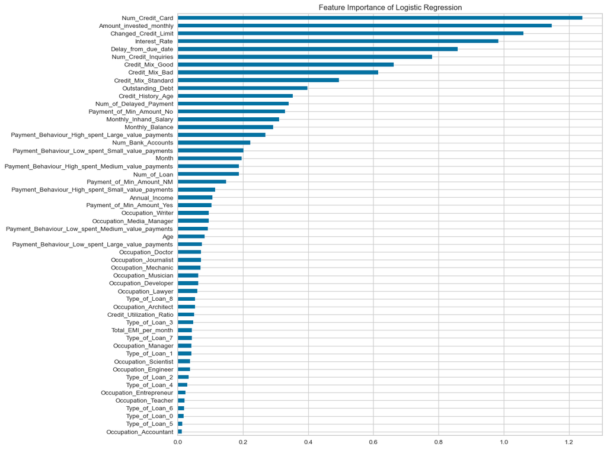

```python
fig, ax = plt.subplots(1, 1, figsize=(12, 12))
pd.Series(np.abs(lg.coef_).mean(axis=0), index=X_train.columns).sort_values(ascending=True).plot.barh(ax=ax, title="Feature Importance of Logistic Regression");
```

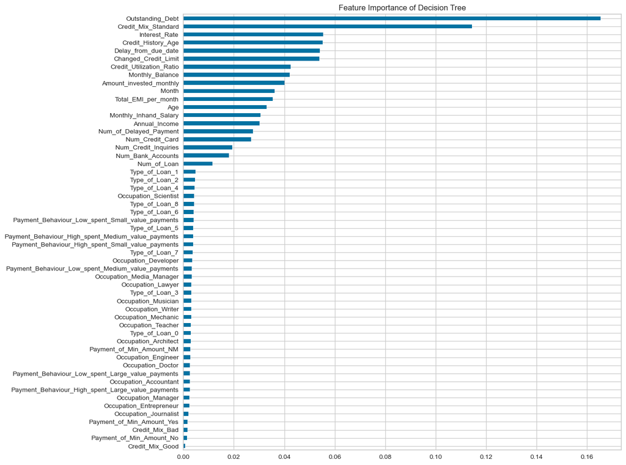

```python
fig, ax = plt.subplots(1, 1, figsize=(12, 12))
pd.Series(tree.feature_importances_, index=X_train.columns).sort_values(ascending=True).plot.barh(ax=ax, title="Feature Importance of Decision Tree");
```

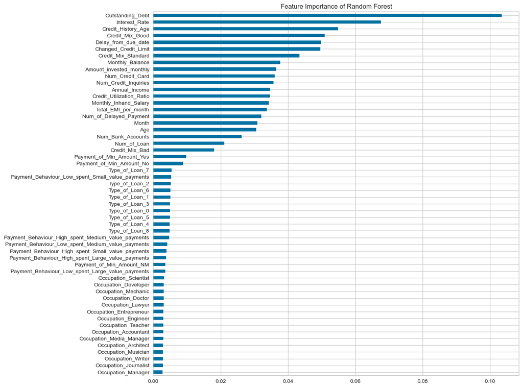

```python
fig, ax = plt.subplots(1, 1, figsize=(12, 12))
pd.Series(forest.feature_importances_, index=X_train.columns).sort_values(ascending=True).plot.barh(ax=ax, title="Feature Importance of Random Forest");
```

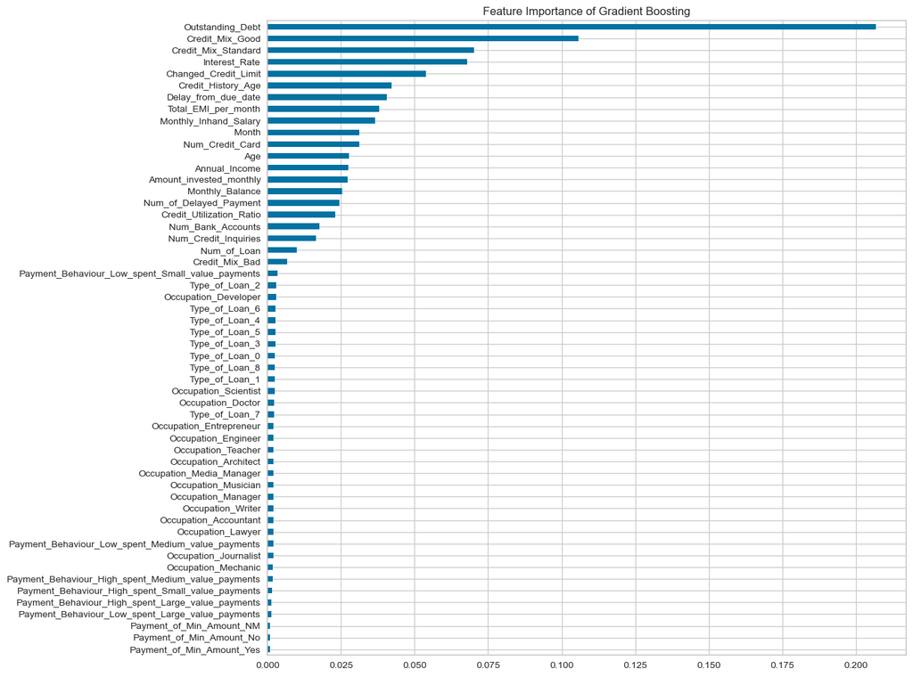

```python
fig, ax = plt.subplots(1, 1, figsize=(12, 12))
pd.Series(boosting.feature_importances_, index=X_train.columns).sort_values(ascending=True).plot.barh(ax=ax, title="Feature Importance of Gradient Boosting");
```

```python
 features_to_drop = [
    'Occupation_Accountant','Occupation_Architect','Occupation_Developer','Occupation_Doctor','Occupation_Engineer',
    'Occupation_Entrepreneur','Occupation_Journalist','Occupation_Lawyer','Occupation_Manager','Occupation_Mechanic',
    'Occupation_Media_Manager','Occupation_Musician','Occupation_Scientist','Occupation_Teacher','Occupation_Writer',
    'Type_of_Loan_0','Type_of_Loan_1','Type_of_Loan_2','Type_of_Loan_3','Type_of_Loan_4','Type_of_Loan_5','Type_of_Loan_6','Type_of_Loan_7','Type_of_Loan_8',
    'Payment_Behaviour_High_spent_Large_value_payments','Payment_Behaviour_High_spent_Medium_value_payments','Payment_Behaviour_High_spent_Small_value_payments',
    'Payment_Behaviour_Low_spent_Large_value_payments','Payment_Behaviour_Low_spent_Medium_value_payments','Payment_Behaviour_Low_spent_Small_value_payments'
]
```

```python
X_train_dropped = X_train.drop(columns=features_to_drop)
X_test_dropped = X_test.drop(columns=features_to_drop)
```

```python
%time lg_dropped = sklearn.linear_model.LogisticRegression(multi_class="multinomial").fit(X_train_dropped, y_train)
```

```
CPU times: total: 5.53 s
Wall time: 982 ms
```

```python
%time tree_dropped = sklearn.tree.DecisionTreeClassifier().fit(X_train_dropped, y_train)
```

```
CPU times: total: 2.19 s
Wall time: 1.19 s
```

```python
%time forest_dropped = sklearn.ensemble.RandomForestClassifier(n_estimators=100, max_depth=25, n_jobs=-1).fit(X_train_dropped, y_train)
```

```
CPU times: total: 29.6 s
Wall time: 2.41 s
```

```python
%time boosting_dropped = sklearn.ensemble.GradientBoostingClassifier(n_estimators=100, max_depth=10).fit(X_train_dropped, y_train)
```

```
CPU times: total: 3min 46s
Wall time: 4min 5s
```

### 5.4 Second Round Comparison

```python
metrics = showMetrics([lg_dropped, tree_dropped, forest_dropped, boosting_dropped], X_train_dropped, y_train, X_test_dropped, y_test)
metrics.style.highlight_max()
```

|  | Test Accuracy | Test Precision (Macro) | Test Recall (Macro) | Test F1 Score (Macro) | Test AUROC (Macro) | Train Accuracy | Train Precision (Macro) | Train Recall (Macro) | Train F1 Score (Macro) | Train AUROC (Macro) |
| --- | --- | --- | --- | --- | --- | --- | --- | --- | --- | --- |
| LogisticRegression | 0.662950 | 0.651412 | 0.640664 | 0.641355 | 0.830789 | 0.660238 | 0.648382 | 0.638329 | 0.638551 | 0.827882 |
| DecisionTreeClassifier | 0.737050 | 0.721080 | 0.721187 | 0.721131 | 0.790810 | 1.000000 | 1.000000 | 1.000000 | 1.000000 | 1.000000 |
| RandomForestClassifier | 0.815550 | 0.809390 | 0.803197 | 0.806209 | 0.937517 | 0.991938 | 0.988590 | 0.994092 | 0.991294 | 0.999864 |
| GradientBoostingClassifier | 0.803900 | 0.795546 | 0.795504 | 0.795525 | 0.929271 | 0.927675 | 0.927942 | 0.926524 | 0.927204 | 0.990742 |

### 5.5 Multicollinearity Analysis

- Only Logistic Regression is sensitive to multicollinearity, we use it to test about the effect of correlated features
- Using VIF as an indicator of the level of multicollinearity
- We pick different thresholds (e.g. 1.5 or 3) and drop corresponding features
- The metrics don't improve significantly and some of them even drop a little bit. We conclude that mulcollinearity in the data doesn't affect much to the performance of Logistic Regression

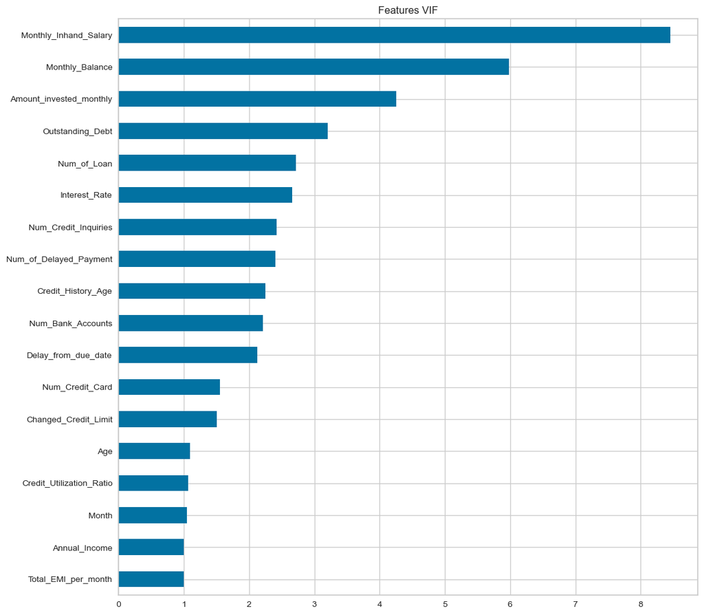

```python
fig, ax = plt.subplots(1, 1, figsize=(12, 12))
pd.Series([statsmodels.stats.outliers_influence.variance_inflation_factor(X_train_dropped, i) for i in range(len(X_train_dropped.columns)-6)],
          index=X_train_dropped.columns[:-6]).sort_values(ascending=True).plot.barh(ax=ax, title="Features VIF");
```

```python
high_vix_columns = ["Monthly_Inhand_Salary", "Monthly_Balance", "Amount_invested_monthly", "Outstanding_Debt"]
X_train_vix = X_train_dropped.drop(columns=high_vix_columns)
X_test_vix = X_test_dropped.drop(columns=high_vix_columns)
```

```python
lg_vix = sklearn.linear_model.LogisticRegression(multi_class="multinomial", class_weight="balanced").fit(X_train_vix, y_train)
metrics = showMetrics([lg_vix], X_train_vix, y_train, X_test_vix, y_test)
metrics.style.highlight_max()
```

|  | Test Accuracy | Test Precision (Macro) | Test Recall (Macro) | Test F1 Score (Macro) | Test AUROC (Macro) | Train Accuracy | Train Precision (Macro) | Train Recall (Macro) | Train F1 Score (Macro) | Train AUROC (Macro) |
| --- | --- | --- | --- | --- | --- | --- | --- | --- | --- | --- |
| LogisticRegression | 0.662000 | 0.699906 | 0.645798 | 0.653326 | 0.831599 | 0.661388 | 0.700101 | 0.646356 | 0.653377 | 0.828176 |

### 5.6 Hyperparameter Tuning

Using GridSearchCV to find optimal hyperparameters of all models.

```python
lg_param_grid = {"penalty": ["l1", "l2"], "C": [0.001, 0.003, 0.01, 0.03, 0.1, 0.03, 1, 3, 10], "solver": ["saga","lbfgs"]}
lg_grid = sklearn.model_selection.GridSearchCV(estimator=sklearn.linear_model.LogisticRegression(multi_class="multinomial"),
                                           param_grid=lg_param_grid, scoring="accuracy", n_jobs=-1, cv=5)
lg_grid.fit(X_train, y_train)
print(lg_grid.best_estimator_)
best_lg = lg_grid.best_estimator_.fit(X_train, y_train)
```

```
LogisticRegression(C=10, multi_class='multinomial', penalty='l1', solver='saga')
```

```python
tree_param_grid = {"criterion": ["gini","entropy"], "max_depth": range(3,50)}
tree_grid = sklearn.model_selection.GridSearchCV(estimator=sklearn.tree.DecisionTreeClassifier(),
                                           param_grid=tree_param_grid, scoring="accuracy", n_jobs=-1, cv=5)
tree_grid.fit(X_train, y_train)
print(tree_grid.best_estimator_)
best_tree = tree_grid.best_estimator_.fit(X_train, y_train)
```

```
DecisionTreeClassifier(criterion='entropy', max_depth=18)
```

```python
forest_param_grid = {"n_estimators": [100, 200, 300], "max_depth": [10, 15, 20, 25, 30]}
forest_grid = sklearn.model_selection.GridSearchCV(estimator=sklearn.ensemble.RandomForestClassifier(),
                                           param_grid=forest_param_grid, scoring="accuracy", n_jobs=-1, cv=5)
forest_grid.fit(X_train, y_train)
print(forest_grid.best_estimator_)
best_forest = forest_grid.best_estimator_.fit(X_train, y_train)
```

```
RandomForestClassifier(max_depth=30, n_estimators=200)
```

```python
boosting_param_grid = {"n_estimators": [100, 200, 300], "learning_rate": [0.01, 0.03, 0.1, 0.3], "max_depth": [10, 15, 20, 25, 30]}
boosting_grid = sklearn.model_selection.GridSearchCV(estimator=sklearn.ensemble.GradientBoostingClassifier(),
                                           param_grid=boosting_param_grid, scoring="accuracy", n_jobs=-1, cv=5)
boosting_grid.fit(X_train, y_train)
print(boosting_grid.best_estimator_)
best_boosting = boosting_grid.best_estimator_.fit(X_train, y_train)
```

```
GradientBoostingClassifier(learning_rate=0.3, max_depth=15, n_estimators=300)
```

## 6. Results and Analysis

### 6.1 Classification Metrics

- Since the labels of dataset is not highly imbalanced, accuracy is a good performance indicator
- In terms of completeness, we also calculate precision, recall, and F1 score for comparison
- As this is a multiclass classification problem, we need to extend definitions for precision, recall, and F1 score. These metrics use the same way of calculation as their binary counterpart for each label and then average the results (one per label)
- Finally, AUROC is also included in our metrics for measuring performance of the classifiers under different threshold values when considering different decision criteria
- ROC curvers are drawn against each labels and macro average for all classifiers.
- Confusion matrices are also calculated for model comparison
- Optimal version of classifiers (obtained through hyperparameter tuning) are used

```python
metrics = showMetrics([best_lg, best_tree, best_forest, best_boosting], X_train, y_train, X_test, y_test)
metrics.style.highlight_max()
```

|  | Test Accuracy | Test Precision (Macro) | Test Recall (Macro) | Test F1 Score (Macro) | Test AUROC (Macro) | Train Accuracy | Train Precision (Macro) | Train Recall (Macro) | Train F1 Score (Macro) | Train AUROC (Macro) |
| --- | --- | --- | --- | --- | --- | --- | --- | --- | --- | --- |
| LogisticRegression | 0.662650 | 0.646814 | 0.640035 | 0.639627 | 0.833703 | 0.661238 | 0.646038 | 0.639188 | 0.638662 | 0.831218 |
| DecisionTreeClassifier | 0.749200 | 0.742192 | 0.731652 | 0.736452 | 0.842977 | 0.885950 | 0.891785 | 0.875138 | 0.882738 | 0.980557 |
| RandomForestClassifier | 0.826150 | 0.821100 | 0.817059 | 0.818927 | 0.941415 | 0.999988 | 0.999992 | 0.999977 | 0.999984 | 1.000000 |
| GradientBoostingClassifier | 0.835700 | 0.830195 | 0.828146 | 0.828928 | 0.944150 | 1.000000 | 1.000000 | 1.000000 | 1.000000 | 1.000000 |

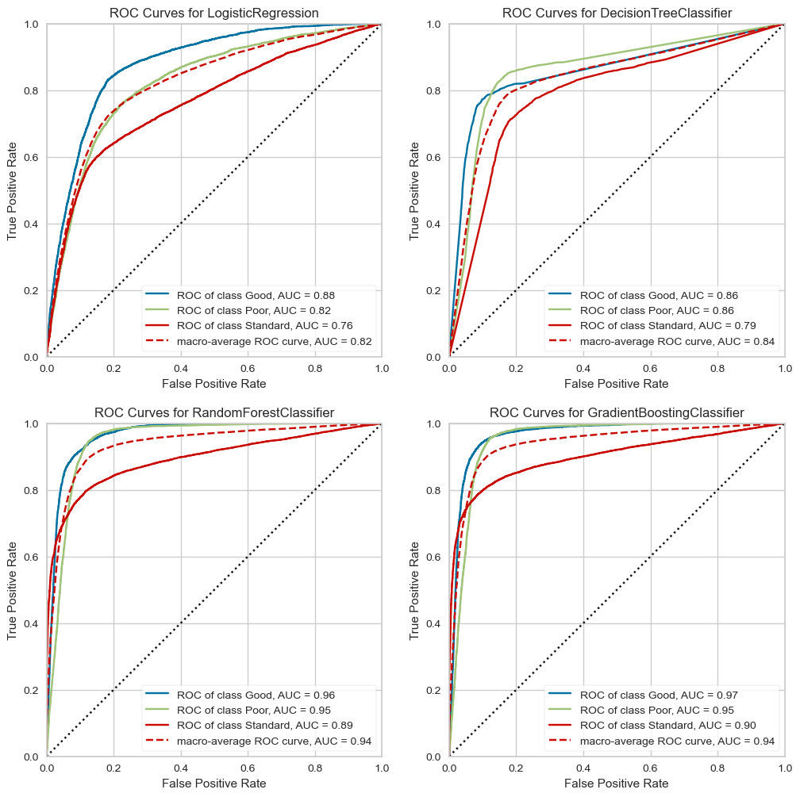

```python
fig, axes = plt.subplots(2, 2, figsize=(12, 12))
plt.sca(axes[0][0])
rocauc_lg = yellowbrick.classifier.roc_auc(best_lg, X_train, y_train, X_test, y_test, classes=credit_score_encoder.classes_, micro=False, is_fitted=True, show=False)
plt.sca(axes[0][1])
rocauc_tree = yellowbrick.classifier.roc_auc(best_tree, X_train, y_train, X_test, y_test, classes=credit_score_encoder.classes_, micro=False, is_fitted=True, show=False)
plt.sca(axes[1][0])
rocauc_forest = yellowbrick.classifier.roc_auc(best_forest, X_train, y_train, X_test, y_test, classes=credit_score_encoder.classes_, micro=False, is_fitted=True, show=False)
plt.sca(axes[1][1])
rocauc_boosting = yellowbrick.classifier.roc_auc(best_boosting, X_train, y_train, X_test, y_test, classes=credit_score_encoder.classes_, micro=False, is_fitted=True)
```

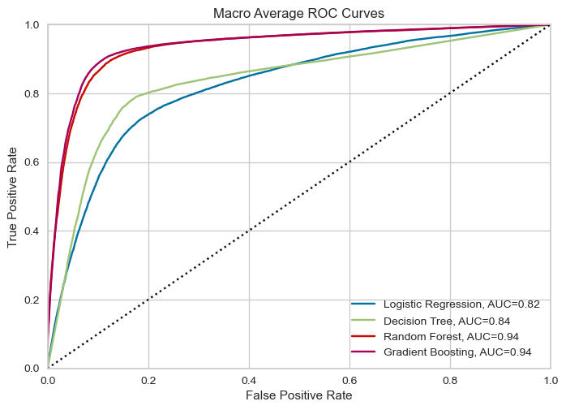

```python
ax = plt.gca()
plt.figure(figsize=(8, 8))
ax.plot(rocauc_lg.fpr["macro"], rocauc_lg.tpr["macro"], label="Logistic Regression, AUC={auc:.2f}".format(auc=rocauc_lg.roc_auc["macro"]))
ax.plot(rocauc_tree.fpr["macro"], rocauc_tree.tpr["macro"], label="Decision Tree, AUC={auc:.2f}".format(auc=rocauc_tree.roc_auc["macro"]))
ax.plot(rocauc_forest.fpr["macro"], rocauc_forest.tpr["macro"], label="Random Forest, AUC={auc:.2f}".format(auc=rocauc_forest.roc_auc["macro"]))
ax.plot(rocauc_boosting.fpr["macro"], rocauc_boosting.tpr["macro"], label="Gradient Boosting, AUC={auc:.2f}".format(auc=rocauc_boosting.roc_auc["macro"]))
ax.plot([0, 1], [0, 1], "k:")
ax.set_xlim(0, 1)
ax.set_ylim(0, 1)
ax.set_xlabel("False Positive Rate")
ax.set_ylabel("True Positive Rate")
ax.set_title("Macro Average ROC Curves")
ax.legend()
plt.show()
```

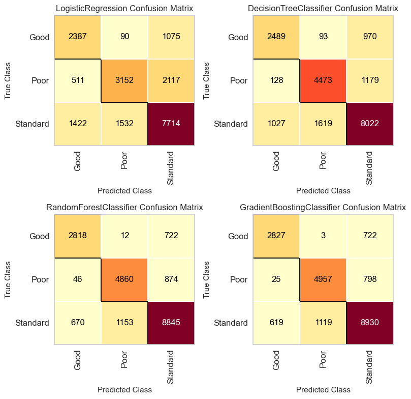

```python
fig, axes = plt.subplots(2, 2, figsize=(8, 8))
plt.sca(axes[0][0])
yellowbrick.classifier.confusion_matrix(best_lg, X_train, y_train, X_test, y_test, classes=credit_score_encoder.classes_, is_fitted=True, show=False)
plt.sca(axes[0][1])
yellowbrick.classifier.confusion_matrix(best_tree, X_train, y_train, X_test, y_test, classes=credit_score_encoder.classes_, is_fitted=True, show=False)
plt.sca(axes[1][0])
yellowbrick.classifier.confusion_matrix(best_forest, X_train, y_train, X_test, y_test, classes=credit_score_encoder.classes_, is_fitted=True, show=False)
plt.sca(axes[1][1])
cm = yellowbrick.classifier.confusion_matrix(best_boosting, X_train, y_train, X_test, y_test, classes=credit_score_encoder.classes_, is_fitted=True)
```

### 6.2 Summary

- After hyperparameter tuning, the optimal gradient boosting classifier excels in all non-time performance metrics
- Random forest classifier is the second, but very close to gradient boosting classifier
- Decision tree classifier is the third, and logistic regression is the last
- Since the data is not highly imbalanced, model performance is consistent across different metrics
- If comparison is based on time efficiency, the ranking will be different and the order is: DecisionTreeClassifier (1.52s), LogisticRegression (7.42s), RandomForestClassifier (36.6s), and GradientBoostingClassifier (4min 36s) in terms of trainig time with the complete training data set (without dropping any column)
- Since RandomForestClassifier has comparable accuracy as GradientBoostingClassifier while possesses good time performance (much better than GradientBoostingClassifer), we recommend using RandomForestCLassifier as the optimal model for this problem

## 7. Discussion and Conclusion

### 7.1 Learning and Takeaways

- Ensemble model performs better than plain tree model
- Random forest classifier has accuracy comparable to gradient boosting classifier, depending on the actual problem and characteristics of the data set
- Decision tree classifier has the fastest training time
- In this data set, due to high dimensionality and nonlinearity, decision tree classifier performs better than logistic regression
- Since gradient boosint classifier is based on serial ensembling algorithm, we cannot exploit the benefit of parallel computing and hence it has longest training time
- Classification metrics defined for binary classification need extension to cope with multiclass classification problem
- In this study, if a model works better than others, it usually performs better in all metrics. This property might be due to characteristics of the data set
- Almost half of the features in this data set don't contribute much to the prediction power of the models

### 7.2 Issue Discussion

- According to the final result, both gradient boosting classifier and randorm forest classifier display certain level of overfitting. As we can see from the performance metrics of training data (most of them are perfect match)
- Due to the size of the data set, we try to include SVM as one of the model initially but give up later because of long training time
- Both gradient boosting classifier and random forest classifier require medium size trees (depth = 10-30) in the ensemble instead of small tree (depth = 1-3) to achieve acceptable performance. The reason of this needs further studying

### 7.3 Possible Future Works

- Other models like KNN, SVM, and deep neural network can be included in this study
- Finding ways to make trees in the ensemble models smaller
- A more thorough study of feature selection, for example, if we can find some subsets of the features which produce better performance than the complete data set?